# GSEA Analysis Report - smartGSEA

SG

smartGSEA Analysis Dashboard

📅 March 12, 2026

🧬 human

⚙️ v0.1.0

# Gene Set Enrichment Analysis

Contrast: M1 vs S1 • Ranking: log2fc • Significance: FDR < 0.05

Total Pathways

📊

198

Significant enrichment (FDR < 0.05)

✓ High confidence

Upregulated

↑

41

Enriched in M1

20.7% of total

Downregulated

↓

157

Enriched in S1

79.3% of total

Gene Coverage

🧬

16,060

Genes analyzed in total

85.6% mapping success

## Enrichment Dotplot Top 30

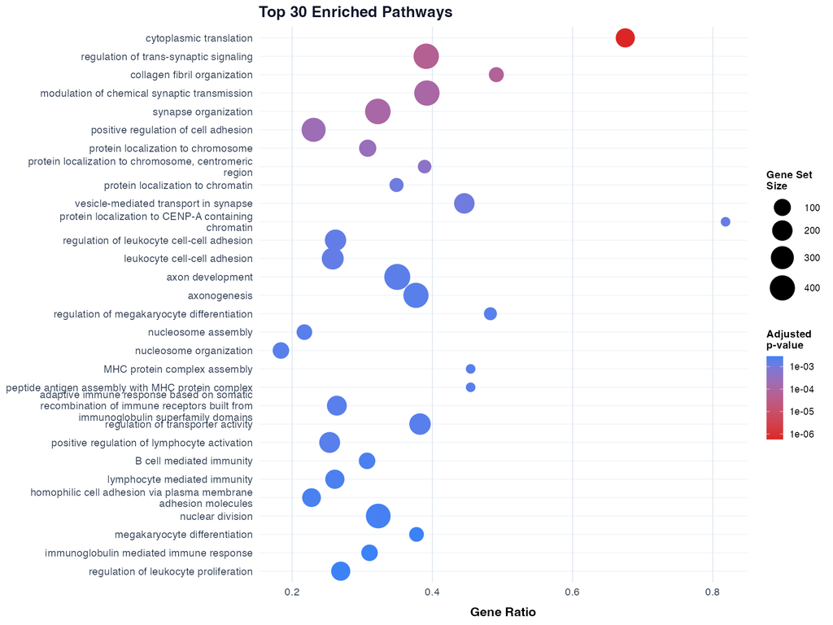

💡 How to Read This Plot

**Gene Ratio (x-axis):** Proportion of genes in the pathway contributing to enrichment  
**Dot size:** Total number of genes in the pathway  
**Dot color:** Statistical significance (red = more significant, blue = less significant)

## Top 5 Pathways - Detailed View

### 1 cytoplasmic translation

↓ Downregulated

Pathway ID

GO:0002181

NES Score

-2.240

Adjusted p-value

5.75e-07

Core Enrichment

106 / 157

Core Enrichment Genes

NCBP2 RPL4 NCK1 EIF3M PKM EIF3H DNAJC24 RPL10 SLBP EIF2B3 RPL8 EIF3L EIF3B EIF3G DRG1 LIN28A RPL13 DENR RPS8 IGF2BP1+ 86 more

### 2 regulation of trans-synaptic signaling

↑ Upregulated

Pathway ID

GO:0099177

NES Score

1.793

Adjusted p-value

5.63e-05

Core Enrichment

160 / 409

Core Enrichment Genes

RASGRF1 ADRA1A ADRA2A ACE GRIK1 NETO1 PHF24 GRID1 ADGRB1 UNC13C KMO SORCS3 DLGAP1 GRIK3 EPHB1 HRH1 CNTNAP4 SLC4A10 CAMK2B GRIK4+ 140 more

### 3 collagen fibril organization

↓ Downregulated

Pathway ID

GO:0030199

NES Score

-2.225

Adjusted p-value

6.67e-05

Core Enrichment

28 / 57

Core Enrichment Genes

LOXL3 SFRP2 LOXL2 TGFB2 CYP1B1 COL1A2 FKBP10 COL5A2 COL18A1 COL11A2 CRTAP P4HA1 EFEMP2 AEBP1 SERPINH1 TLL1 COL5A1 FOXC2 COL11A1 LOXL4+ 8 more

### 4 modulation of chemical synaptic transmission

↑ Upregulated

Pathway ID

GO:0050804

NES Score

1.798

Adjusted p-value

1.15e-04

Core Enrichment

160 / 408

Core Enrichment Genes

RASGRF1 ADRA1A ADRA2A ACE GRIK1 NETO1 PHF24 GRID1 ADGRB1 UNC13C KMO SORCS3 DLGAP1 GRIK3 EPHB1 HRH1 CNTNAP4 SLC4A10 CAMK2B GRIK4+ 140 more

### 5 synapse organization

↑ Upregulated

Pathway ID

GO:0050808

NES Score

1.786

Adjusted p-value

1.15e-04

Core Enrichment

135 / 419

Core Enrichment Genes

PCDHB5 SRPX2 IL10RA ASIC2 SEMA3E THBS2 SPTB SLIT1 GRID1 ADGRB1 UNC13C IGSF21 WNT7B ITGB3 EPHB1 CAMK2B SLC6A1 MAPT DNM3 ERBB4+ 115 more

## Complete Results

| Pathway ID | Description | Direction | Gene Ratio | Set Size | NES | p-value | Adj. p-value | Genes |
| --- | --- | --- | --- | --- | --- | --- | --- | --- |
| GO:0002181 | **cytoplasmic translation** | ↓ Down | 106 / 157 | 157 | -2.24 | 1.00e-10 | 5.75e-07 | NCBP2, RPL4, NCK1, EIF3M, PKM, EIF3H, DNAJC24, RPL10, SLBP, EIF2B3, ... |
| GO:0099177 | **regulation of trans-synaptic signaling** | ↑ Up | 160 / 409 | 409 | 1.79 | 1.96e-08 | 5.63e-05 | RASGRF1, ADRA1A, ADRA2A, ACE, GRIK1, NETO1, PHF24, GRID1, ADGRB1, UNC13C, ... |
| GO:0030199 | **collagen fibril organization** | ↓ Down | 28 / 57 | 57 | -2.22 | 3.48e-08 | 6.67e-05 | LOXL3, SFRP2, LOXL2, TGFB2, CYP1B1, COL1A2, FKBP10, COL5A2, COL18A1, COL11A2, ... |
| GO:0050804 | **modulation of chemical synaptic transmission** | ↑ Up | 160 / 408 | 408 | 1.80 | 9.99e-08 | 1.15e-04 | RASGRF1, ADRA1A, ADRA2A, ACE, GRIK1, NETO1, PHF24, GRID1, ADGRB1, UNC13C, ... |
| GO:0050808 | **synapse organization** | ↑ Up | 135 / 419 | 419 | 1.79 | 8.63e-08 | 1.15e-04 | PCDHB5, SRPX2, IL10RA, ASIC2, SEMA3E, THBS2, SPTB, SLIT1, GRID1, ADGRB1, ... |
| GO:0045785 | **positive regulation of cell adhesion** | ↓ Down | 80 / 347 | 347 | -1.77 | 2.34e-07 | 2.24e-04 | PTPN6, TGFB2, ADAM9, HYAL1, IGF2, EPHA1, NDNF, DOCK1, TNFRSF13C, FOXP3, ... |
| GO:0034502 | **protein localization to chromosome** | ↓ Down | 32 / 104 | 104 | -2.05 | 3.27e-07 | 2.68e-04 | RCC2, MTBP, EZH2, RPA1, TERT, LEF1, HASPIN, CENPQ, PIH1D1, BUB1B, ... |
| GO:0071459 | **protein localization to chromosome, centromeric region** | ↓ Down | 14 / 36 | 36 | -2.18 | 6.67e-07 | 4.79e-04 | KNL1, H4C5, NDC80, CDK1, H4C14, AURKB, H2BC11, CENPA, H4C9, H2AC8, ... |
| GO:0071168 | **protein localization to chromatin** | ↓ Down | 15 / 43 | 43 | -2.13 | 1.89e-06 | 1.16e-03 | CDCA5, MCM9, VRK1, ESCO2, PLK1, H4C5, H4C14, H2BC11, CENPA, H4C9, ... |
| GO:0099003 | **vesicle-mediated transport in synapse** | ↑ Up | 90 / 202 | 202 | 1.90 | 2.01e-06 | 1.16e-03 | PLD1, SLC17A6, RPH3A, UNC13C, DOC2B, SH3GL2, GSG1L, ITGB3, DNM3, NSG1, ... |
| GO:0061644 | **protein localization to CENP-A containing chromatin** | ↓ Down | 9 / 11 | 11 | -1.98 | 2.77e-06 | 1.45e-03 | H4C14, H2BC11, CENPA, H4C9, H2AC8, H4C8, H4C16, H4C15, H4C11 |
| GO:1903037 | **regulation of leukocyte cell-cell adhesion** | ↓ Down | 61 / 233 | 233 | -1.77 | 3.40e-06 | 1.54e-03 | CXCL12, ALOX5, NRARP, VTCN1, ZAP70, LOXL3, ZBTB16, AP3B1, RPS3, SOCS1, ... |
| GO:0007159 | **leukocyte cell-cell adhesion** | ↓ Down | 66 / 256 | 256 | -1.75 | 3.48e-06 | 1.54e-03 | CXCL12, ALOX5, NRARP, VTCN1, ITGB1, ZAP70, LOXL3, ZBTB16, AP3B1, RPS3, ... |
| GO:0061564 | **axon development** | ↑ Up | 155 / 443 | 443 | 1.63 | 4.27e-06 | 1.75e-03 | ARX, ISLR2, EPHA8, SEMA3E, EPHA10, SLIT1, RET, ADGRB1, FOXG1, NRXN3, ... |
| GO:0007409 | **axonogenesis** | ↑ Up | 151 / 401 | 401 | 1.67 | 4.91e-06 | 1.88e-03 | ARX, ISLR2, EPHA8, SEMA3E, EPHA10, SLIT1, RET, ADGRB1, FOXG1, NRXN3, ... |
| GO:0045652 | **regulation of megakaryocyte differentiation** | ↓ Down | 14 / 29 | 29 | -2.06 | 7.27e-06 | 1.90e-03 | MEF2C, ZNF16, HMGB2, H4C5, GATA2, H4C14, CIB1, LOX, H4C9, TESC, ... |
| GO:0006334 | **nucleosome assembly** | ↓ Down | 15 / 69 | 69 | -2.06 | 7.09e-06 | 1.90e-03 | H4C5, H2BC9, H1-2, ASF1B, H2BC6, H4C14, H2BC11, H2BC4, H3C6, H4C9, ... |
| GO:0034728 | **nucleosome organization** | ↓ Down | 16 / 87 | 87 | -2.03 | 7.54e-06 | 1.90e-03 | H4C5, H2BC9, H1-2, ASF1B, H2BC6, H4C14, H2BC11, H2BC4, H3C6, H4C9, ... |
| GO:0002396 | **MHC protein complex assembly** | ↓ Down | 5 / 11 | 11 | -1.95 | 6.18e-06 | 1.90e-03 | B2M, HLA-DQB1, HLA-DMA, HLA-DPA1, HLA-DOA |
| GO:0002501 | **peptide antigen assembly with MHC protein complex** | ↓ Down | 5 / 11 | 11 | -1.95 | 6.18e-06 | 1.90e-03 | B2M, HLA-DQB1, HLA-DMA, HLA-DPA1, HLA-DOA |
| GO:0002460 | **adaptive immune response based on somatic recombination of immune receptors built from immunoglobulin superfamily domains** | ↓ Down | 48 / 182 | 182 | -1.83 | 6.49e-06 | 1.90e-03 | PTPN6, TCIRG1, C2, FOXP3, SVEP1, FZD5, NFKB2, BCL6, CD55, SEMA4A, ... |
| GO:0032409 | **regulation of transporter activity** | ↑ Up | 91 / 238 | 238 | 1.81 | 6.35e-06 | 1.90e-03 | APOA2, RASGRF1, TRPC6, ADRA2A, SYNGR3, TRDN, NETO1, TCAF2, NEDD4L, GSG1L, ... |
| GO:0051251 | **positive regulation of lymphocyte activation** | ↓ Down | 55 / 217 | 217 | -1.74 | 7.62e-06 | 1.90e-03 | VTCN1, MEF2C, ZAP70, ZBTB16, WNT3A, AP3B1, SHLD1, RPS3, SOCS1, PTPN6, ... |
| GO:0019724 | **B cell mediated immunity** | ↓ Down | 27 / 88 | 88 | -1.99 | 9.98e-06 | 2.32e-03 | PTPN6, TCIRG1, C2, FOXP3, SVEP1, BCL6, CD55, C1S, CD74, TREX1, ... |
| GO:0002449 | **lymphocyte mediated immunity** | ↓ Down | 42 / 161 | 161 | -1.84 | 1.01e-05 | 2.32e-03 | PTPN6, TCIRG1, C2, FOXP3, SVEP1, FZD5, BCL6, CD55, PRDX1, C1S, ... |
| GO:0007156 | **homophilic cell adhesion via plasma membrane adhesion molecules** | ↑ Up | 33 / 145 | 145 | 1.98 | 1.09e-05 | 2.41e-03 | PCDHB5, PCDHA2, PCDHA3, PCDHA9, PCDHGB4, PCDHGA10, PCDHGB5, PTPRT, PCDHA10, PCDHB15, ... |
| GO:0000280 | **nuclear division** | ↓ Down | 122 / 378 | 378 | -1.60 | 1.19e-05 | 2.52e-03 | UBB, CENPE, NCAPD3, CHMP6, MTBP, FANCD2, RAD54L, ANAPC11, NPR2, NDC1, ... |
| GO:0030219 | **megakaryocyte differentiation** | ↓ Down | 20 / 53 | 53 | -2.03 | 1.59e-05 | 2.88e-03 | MEF2C, ZNF16, TAL1, HMGB2, PTPN6, MAF, H4C5, GATA2, H4C14, CIB1, ... |
| GO:0016064 | **immunoglobulin mediated immune response** | ↓ Down | 27 / 87 | 87 | -1.99 | 1.47e-05 | 2.88e-03 | PTPN6, TCIRG1, C2, FOXP3, SVEP1, BCL6, CD55, C1S, CD74, TREX1, ... |
| GO:0070663 | **regulation of leukocyte proliferation** | ↓ Down | 42 / 156 | 156 | -1.81 | 1.59e-05 | 2.88e-03 | PTPN6, IGF2, TNFRSF9, GSTP1, TACR1, TNFRSF13C, FOXP3, TNFSF9, BCL6, CD55, ... |

[output cut: 168 more lines]

## 📖 Methods & Documentation

### Analysis Pipeline

This Gene Set Enrichment Analysis was performed using **smartGSEA v0.1.0**, implementing the GSEA algorithm (Subramanian et al., 2005) via clusterProfiler (Yu et al., 2012).

#### 1. Data Preparation

- **Input:** DESeq2 differential expression results
- **Contrast:** M1 vs S1
- **Total genes:** 16,060
- **Approach:** All genes included (no pre-filtering on significance)

#### 2. Gene ID Conversion

- **Method:** clusterProfiler bitr() function
- **Conversion:** ENSEMBL → ENTREZ gene IDs
- **Organism:** human (auto-detected)
- **Success rate:** 85.6%
- **Duplicate handling:** Retained gene with highest |ranking metric|

#### 3. Gene Ranking

- **Metric:** log2fc
- **Sort order:** Descending

#### 4. GSEA Execution

- **Algorithm:** Fast Gene Set Enrichment Analysis (fGSEA)
- **Gene sets:** Gene Ontology Biological Process (GO:BP)
- **Permutations:** 1,000
- **Gene set size:** 10–500 genes

#### 5. Multiple Testing Correction

- **Method:** Benjamini-Hochberg FDR
- **Threshold:** FDR < 0.05
- **Critical:** Filtered on **adjusted p-values** (not nominal)

⚠️ Why This Matters

The default pvalueCutoff in clusterProfiler filters on nominal p-values, inflating results by 5–10×. smartGSEA enforces proper FDR filtering to ensure only statistically significant pathways are reported.

### 📚 References

1. **GSEA methodology:** Subramanian A, Tamayo P, Mootha VK, et al. (2005). Gene set enrichment analysis: A knowledge-based approach for interpreting genome-wide expression profiles. *PNAS*, 102(43), 15545–15550.
2. **clusterProfiler:** Yu G, Wang LG, Han Y, He QY (2012). clusterProfiler: an R package for comparing biological themes among gene clusters. *OMICS: A Journal of Integrative Biology*, 16(5), 284–287.
3. **FDR correction:** Benjamini Y, Hochberg Y (1995). Controlling the false discovery rate: a practical and powerful approach to multiple testing. *Journal of the Royal Statistical Society Series B*, 57(1), 289–300.
4. **smartGSEA:** Samuel GH (2025). smartGSEA: Streamlined GSEA from DESeq2 results. R package version 0.1.0. https://github.com/ghsamuel/smartGSEA

### 📝 How to Cite

Gene Set Enrichment Analysis was performed using smartGSEA v0.1.0 (Samuel, 2025), implementing the GSEA algorithm (Subramanian et al., 2005) via clusterProfiler (Yu et al., 2012). Pathways with FDR < 0.05 were considered statistically significant.

**Report Generated:** March 12, 2026 at 17:07 EDT  
**Analysis Platform:** smartGSEA v0.1.0  
[📚 Documentation & Source Code](https://github.com/ghsamuel/smartGSEA)